# Analytics Project 3

Donna Baret

May 1, 2019

# Orange Customer Retention

## Introduction

Technology is fast changing and so are the customer’s needs. We have seen a shift from SMS and Call to purely Data interactions. In this paper we examine a telecommunications company Orange and its competitors and answer the question: What makes a customer stay as an Orange subscriber?

We will help Orange maximize profit and prevent attrition by finding out the reasons why customers stay. Hence, we will use Principal Component Analysis and Clustering techniques in order to identify the importance features of a telco data and identifying typical postpaid customer behavior.

We will particularly use PCA to differentiate the major sources of variations in the data, simplify the data by describing customer behavior with fewer features and identify atypical behaviors. On the other hand, we will be using Cluster Analysis to suggest several prototypes of behavior existing in the data and describe how each prototype is related to churning.

Finally, we will be applying regularization in order to construct an interpretable and actionable model that predicts which customer are likely to churn after two months. We will also be discussing potential indicators or “warning signals” for customer churn.

## Background

There are different reasons in addition to bad service why customers leave a network, in Orange’s case, with its flexible plan offers, it brings certain costs. Some customers leave because they might have gotten the wrong subscription and miscalculated the consumption and thus might result to a failed payment. In other scenarios, a better alternative might have been chosen by the customer, in which it can be observed by increasing texts to other telco providers and by the declining calls, SMS, and data usage.

## Data Preparation and Framework

1. Data Preprocessing -we have done some data reduction techniques for monthly variables and reduced 5 month data into sums, differences, and average. From 99 variables, we have redeced it to 29 variables by data reduction techniques
   - Usage Trend - difference in usage between 1st month of subscription vs. 5th month of subscription(SMS, Call, Data)
   - Actual vs Plan Used - Difference in set data plan vs mean 5-month actual plan usage
   - 5 month Sum - SMS Call Data consumed, SMS revenue, Call Revenue, Data Revenue, Onnet Revenue and Offnet revenue
2. Cluster Analysis - we have done a boxplot visualisation and Selected variables that have noticeable difference on values between being churned or not

We have reduced the variables from 98 to 27 variables, excluding categorical data which are churn and location.

```r
str(data.repository)
```

```
## 'data.frame':    16926 obs. of  27 variables:
##  $ orange_customer_data$sms_pax      : num  100 100 0 50 50 50 50 50 200 50 ...
##  $ orange_customer_data$call_pax     : num  0 100 0 0 0 0 0 100 0 0 ...
##  $ orange_customer_data$data_pax     : num  2048 0 2048 4096 4096 ...
##  $ orange_customer_data$other_rev    : num  0 0 0 0 0 0 275 0 0 0 ...
##  $ orange_customer_data$network_age  : num  37 91 85 92 82 93 22 80 89 82 ...
##  $ orange_customer_data$service_calls: int  0 0 1 0 0 2 1 0 0 0 ...
##  $ orange_customer_data$plan_fare    : num  575 475 500 840 840 840 540 940 650 540 ...
##  $ sms.thresh.diff                   : num  42.6 39.2 -33 11.6 40.4 ...
##  $ sms.trend.diff                    : num  0 6 -2 4 0 -4 1 7 42 -1 ...
##  $ sms.berry.5                       : num  68 93 56 60 20 20 39 49 995 38 ...
##  $ sms.lemon.5                       : num  74 114 55 56 11 20 49 53 513 41 ...
##  $ sms.orange.5                      : num  145 97 54 76 17 31 64 67 745 46 ...
##  $ sms.revenue.5                     : num  375 375 165 200 200 200 200 200 1780 200 ...
##  $ sms.5                             : num  287 304 165 192 48 ...
##  $ call.trend.diff                   : num  -1 0 0 1 0 -1 3 1 -3 -3 ...
##  $ call.thresh.diff                  : num  -6.2 63.2 -9.2 -7.6 -4 -2.8 -9.6 65.6 -15.2 -7.6 ...
##  $ call.berry.5                      : num  7 48 16 13 9 4 12 50 23 10 ...
##  $ call.lemon.5                      : num  8 83 14 12 3 4 16 53 27 11 ...
##  $ call.orange.5                     : num  16 53 16 13 8 6 20 69 26 17 ...
##  $ call.revenue.5                    : num  206 2000 323 269 140 ...
##  $ call.5                            : num  31 184 46 38 20 14 48 172 76 38 ...
##  $ data.thresh.diff                  : num  445 -714 150 411 4046 ...
##  $ data.trend.diff                   : num  2 184 219 105 -31 ...
##  $ data.revenue.5                    : num  2836 5284 2871 4050 4100 ...
##  $ data.5                            : num  31 184 46 38 20 14 48 172 76 38 ...
##  $ offnet.revenue.5                  : num  123.8 1212.5 195.2 93.6 104.3 ...
##  $ onnet.revenue.5                   : num  458 1163 293 375 236 ...
```

```r
sum(orange_customer_data$churn)/nrow(orange_customer_data$churn) #churn rate
```

```
## [1] 0.3053291
```

Preliminary analysis shows that churn rate is 31%,

## Principal Component Analysis

```
## Importance of components:
##                           PC1    PC2     PC3     PC4     PC5     PC6
## Standard deviation     2.9928 2.0267 1.55556 1.44879 1.18907 1.16086
## Proportion of Variance 0.3317 0.1521 0.08962 0.07774 0.05237 0.04991
## Cumulative Proportion  0.3317 0.4839 0.57349 0.65123 0.70360 0.75351
##                            PC7     PC8     PC9    PC10    PC11   PC12
## Standard deviation     1.02656 1.00193 0.99471 0.95626 0.93064 0.8150
## Proportion of Variance 0.03903 0.03718 0.03665 0.03387 0.03208 0.0246
## Cumulative Proportion  0.79254 0.82972 0.86637 0.90024 0.93231 0.9569
##                           PC13    PC14    PC15    PC16    PC17    PC18
## Standard deviation     0.56773 0.49279 0.40637 0.36106 0.31104 0.27731
## Proportion of Variance 0.01194 0.00899 0.00612 0.00483 0.00358 0.00285
## Cumulative Proportion  0.96885 0.97785 0.98396 0.98879 0.99237 0.99522
##                           PC19    PC20    PC21      PC22     PC23
## Standard deviation     0.24511 0.20715 0.16136 1.603e-13 1.21e-13
## Proportion of Variance 0.00223 0.00159 0.00096 0.000e+00 0.00e+00
## Cumulative Proportion  0.99745 0.99904 1.00000 1.000e+00 1.00e+00
##                             PC24      PC25      PC26      PC27
## Standard deviation     4.031e-15 3.583e-15 1.498e-15 1.977e-16
## Proportion of Variance 0.000e+00 0.000e+00 0.000e+00 0.000e+00
## Cumulative Proportion  1.000e+00 1.000e+00 1.000e+00 1.000e+00
```

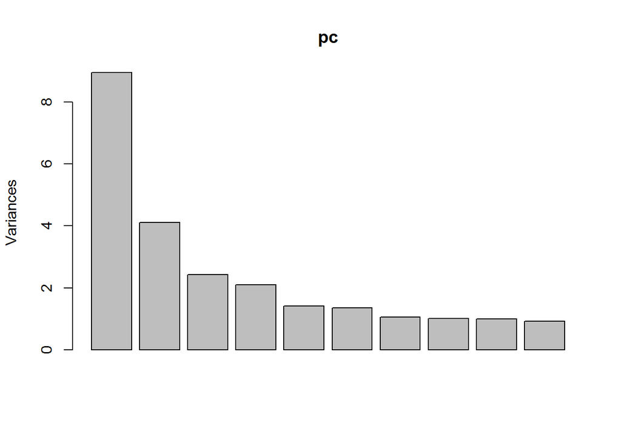

As we can from above, we choose eigenvectors with standard deviation greater than 1. Thus selecting the first eight principal components

```
##                                              PC1           PC2
## orange_customer_data$sms_pax       -0.1363978205  0.3025038936
## orange_customer_data$call_pax      -0.1889094897 -0.2306611841
## orange_customer_data$data_pax       0.1099450064 -0.0091574529
## orange_customer_data$other_rev     -0.0226117911 -0.0122060336
## orange_customer_data$network_age   -0.0848463105 -0.0079142631
## orange_customer_data$service_calls  0.0374765148 -0.0275484712
## orange_customer_data$plan_fare      0.0136896431 -0.0786570586
## sms.thresh.diff                     0.1392329292 -0.0942406900
## sms.trend.diff                     -0.0028594978  0.0027867391
## sms.berry.5                        -0.2268731635  0.3284154560
## sms.lemon.5                        -0.2251886526  0.3329083874
## sms.orange.5                       -0.2099150513  0.3403157416
## sms.revenue.5                      -0.2072464742  0.3421884035
## sms.5                              -0.2311551826  0.3502357014
## call.trend.diff                    -0.0064798077 -0.0208708988
## call.thresh.diff                    0.0320589029 -0.1102441844
## call.berry.5                       -0.2874460689 -0.1763991417
## call.lemon.5                       -0.2881679299 -0.1796781478
## call.orange.5                      -0.2852229992 -0.1892838712
## call.revenue.5                     -0.2863176769 -0.2233261775
## call.5                             -0.2984139971 -0.1891074887
## data.thresh.diff                    0.0123474626 -0.0367938370
## data.trend.diff                    -0.0018389151  0.0070432707
## data.revenue.5                     -0.0003603322  0.0002153302
## data.5                             -0.2984139971 -0.1891074887
## offnet.revenue.5                   -0.3193731113 -0.0598456237
## onnet.revenue.5                    -0.2279750885 -0.1633936600
##                                             PC3           PC4          PC5
## orange_customer_data$sms_pax       -0.278278040  0.1588153096 -0.018388852
## orange_customer_data$call_pax      -0.358591391  0.1111821593 -0.183549720
## orange_customer_data$data_pax       0.267526414  0.5650646004  0.117550018
## orange_customer_data$other_rev     -0.015923005 -0.0206290554  0.040634020
## orange_customer_data$network_age    0.189621921 -0.0463168082  0.069829176
## orange_customer_data$service_calls -0.104530056  0.1560845256  0.102568611
## orange_customer_data$plan_fare      0.069827626  0.6514724125  0.065546940
## sms.thresh.diff                    -0.331228095  0.1458414057 -0.011423826
## sms.trend.diff                      0.034353882 -0.0113344468  0.041576563
## sms.berry.5                         0.001999932  0.0339223840  0.028488352
## sms.lemon.5                         0.020344989  0.0307529308 -0.028071297
```

[output cut: 29 more lines]

```
## sms.revenue.5                      -0.061946862 -0.10679107  0.015025060
## sms.5                               0.023261777  0.08774181 -0.006728298
## call.trend.diff                     0.691506894 -0.08719310 -0.062664349
## call.thresh.diff                    0.062317104  0.17536847  0.004084900
## call.berry.5                       -0.016413704 -0.03215845 -0.013349752
## call.lemon.5                       -0.004490173 -0.02301043 -0.012875985
## call.orange.5                      -0.009183760 -0.02883604 -0.003959528
## call.revenue.5                      0.001786820  0.02079701 -0.002985830
## call.5                             -0.010452928 -0.02914998 -0.010421674
## data.thresh.diff                   -0.038860587 -0.01355639 -0.005640208
## data.trend.diff                    -0.081041478 -0.07685723 -0.824308509
## data.revenue.5                      0.004260223 -0.09082459  0.020622355
## data.5                             -0.010452928 -0.02914998 -0.010421674
## offnet.revenue.5                    0.008173954  0.06015683 -0.016113135
## onnet.revenue.5                    -0.049454513 -0.12252343  0.029646904
```

Looking at the high loadings on the PC rotation, we can summarize the major sources of variation into 8 components:

We categorize these eight principal components and namely

3.**PC3: Low Data Plan Low Data User** : These users planned their their data plan correctly and most like have WiFi in their homes/offices

4. ** PC4: Low SMS Plan, Overused Call minutes**: These are also subscribers that has miscalculated their call plans.
5. **PC5: Overused Data** : These users have overused their allotted data plan

6.** PC6: Overused SMS and Decreasing Call**: These users has overused their SMS plan threshold and we also saw decreasing call trend for the past 5 months

7. **PC7:Underused SMS and Old Network Age** : Probably old users who avails an SMS plan
8. **PC8: Low Number of Registration to Other Promo , high service calls, increasing data users.**: Users who are enjoying the data plan.

```
##       Min.    1st Qu.     Median       Mean    3rd Qu.       Max.
## -2.109e-15 -9.714e-17  0.000e+00  1.135e-18  9.888e-17  2.387e-15
```

```
## [1] orange_customer_data$churn offnet.revenue.5
## [3] call.5                     call.revenue.5
## [5] PC27
## <0 rows> (or 0-length row.names)
```

Moreover, we can see that there are no outlying data.

## Cluster Analysis

For the Cluster Analysis, we have graphed a box plot in order to see how each value will differ betweet the churned member and the staying member. This is to see potential indicator of a churn better.

```
## 'data.frame':    16926 obs. of  8 variables:
##  $ orange_customer_data$network_age  : num  37 91 85 92 82 93 22 80 89 82 ...
##  $ orange_customer_data$service_calls: int  0 0 1 0 0 2 1 0 0 0 ...
##  $ sms.thresh.diff                   : num  42.6 39.2 -33 11.6 40.4 ...
##  $ sms.5                             : num  287 304 165 192 48 ...
##  $ call.5                            : num  31 184 46 38 20 14 48 172 76 38 ...
##  $ data.thresh.diff                  : num  445 -714 150 411 4046 ...
##  $ data.trend.diff                   : num  2 184 219 105 -31 ...
##  $ offnet.revenue.5                  : num  123.8 1212.5 195.2 93.6 104.3 ...
```

```
## 'data.frame':    16926 obs. of  29 variables:
##  $ orange_customer_data$sms_pax      : num  100 100 0 50 50 50 50 50 200 50 ...
##  $ orange_customer_data$call_pax     : num  0 100 0 0 0 0 0 100 0 0 ...
##  $ orange_customer_data$data_pax     : num  2048 0 2048 4096 4096 ...
##  $ orange_customer_data$other_rev    : num  0 0 0 0 0 0 275 0 0 0 ...
##  $ orange_customer_data$network_age  : num  37 91 85 92 82 93 22 80 89 82 ...
##  $ orange_customer_data$service_calls: int  0 0 1 0 0 2 1 0 0 0 ...
##  $ orange_customer_data$plan_fare    : num  575 475 500 840 840 840 540 940 650 540 ...
##  $ sms.thresh.diff                   : num  42.6 39.2 -33 11.6 40.4 ...
##  $ sms.trend.diff                    : num  0 6 -2 4 0 -4 1 7 42 -1 ...
##  $ sms.berry.5                       : num  68 93 56 60 20 20 39 49 995 38 ...
##  $ sms.lemon.5                       : num  74 114 55 56 11 20 49 53 513 41 ...
##  $ sms.orange.5                      : num  145 97 54 76 17 31 64 67 745 46 ...
##  $ sms.revenue.5                     : num  375 375 165 200 200 200 200 200 1780 200 ...
##  $ sms.5                             : num  287 304 165 192 48 ...
##  $ call.trend.diff                   : num  -1 0 0 1 0 -1 3 1 -3 -3 ...
##  $ call.thresh.diff                  : num  -6.2 63.2 -9.2 -7.6 -4 -2.8 -9.6 65.6 -15.2 -7.6 ...
##  $ call.berry.5                      : num  7 48 16 13 9 4 12 50 23 10 ...
##  $ call.lemon.5                      : num  8 83 14 12 3 4 16 53 27 11 ...
##  $ call.orange.5                     : num  16 53 16 13 8 6 20 69 26 17 ...
##  $ call.revenue.5                    : num  206 2000 323 269 140 ...
##  $ call.5                            : num  31 184 46 38 20 14 48 172 76 38 ...
##  $ data.thresh.diff                  : num  445 -714 150 411 4046 ...
##  $ data.trend.diff                   : num  2 184 219 105 -31 ...
##  $ data.revenue.5                    : num  2836 5284 2871 4050 4100 ...
##  $ data.5                            : num  31 184 46 38 20 14 48 172 76 38 ...
##  $ offnet.revenue.5                  : num  123.8 1212.5 195.2 93.6 104.3 ...
##  $ onnet.revenue.5                   : num  458 1163 293 375 236 ...
##  $ orange_customer_data$churn        : num  1 0 0 0 1 1 0 0 0 1 ...
##  $ orange_customer_data$location     : int  7 7 7 3 2 6 7 4 5 4 ...
```

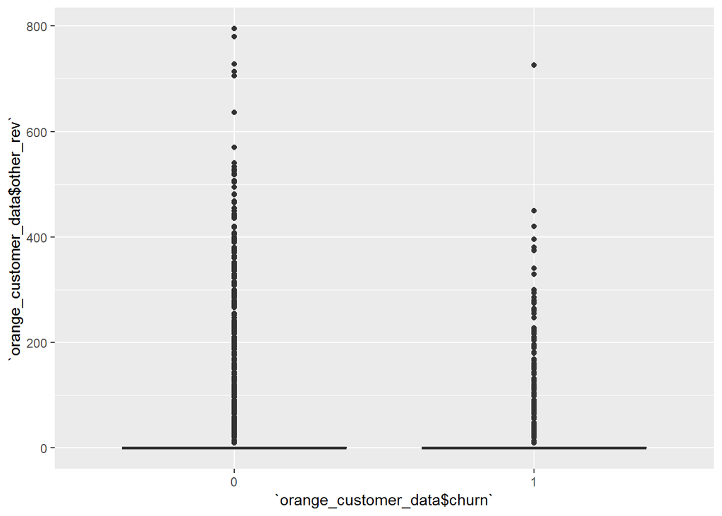

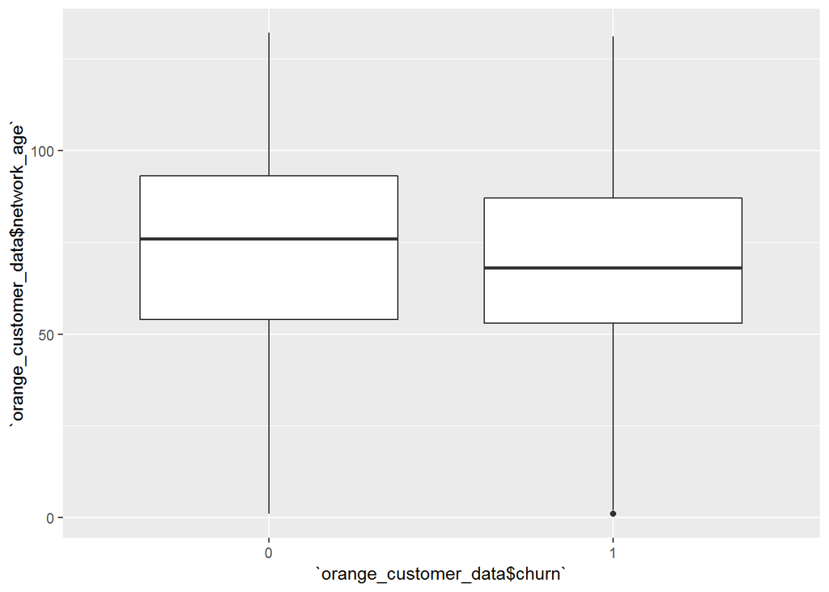

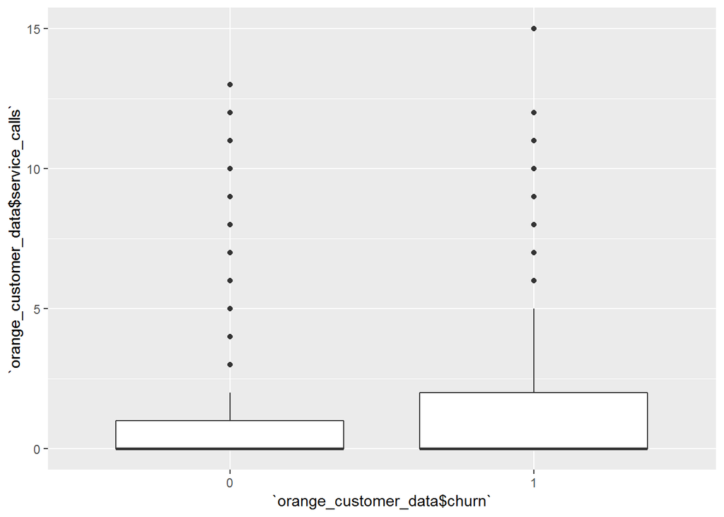

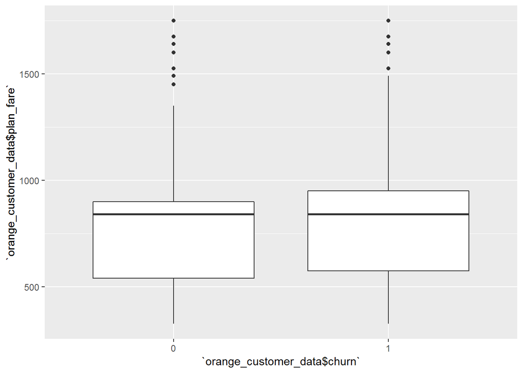

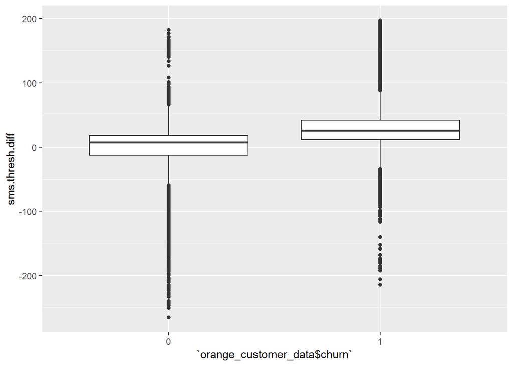

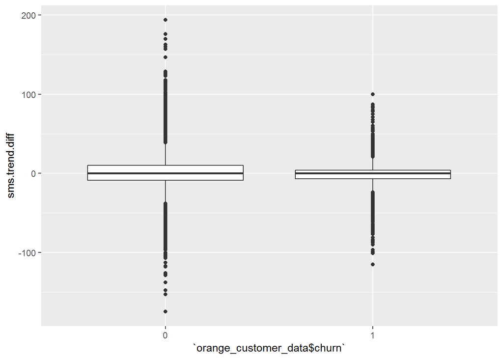

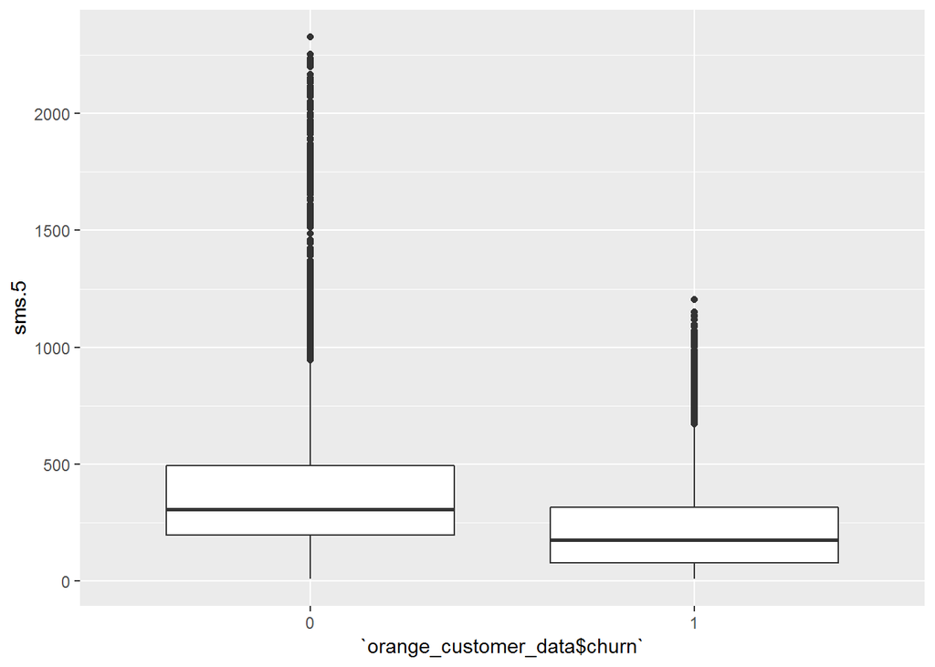

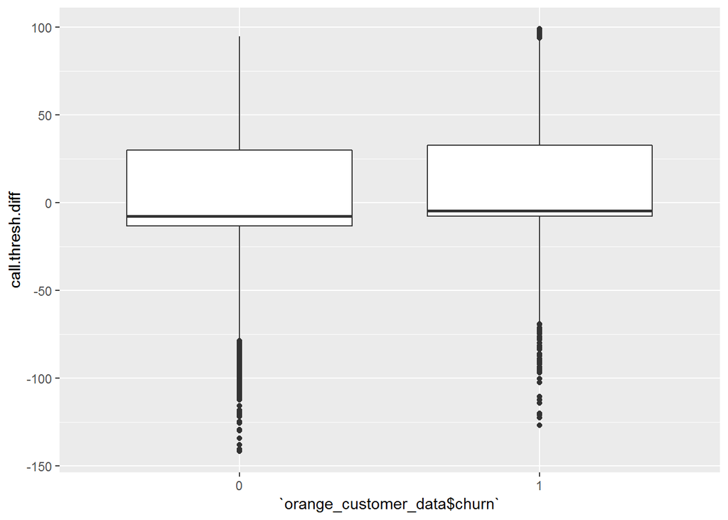

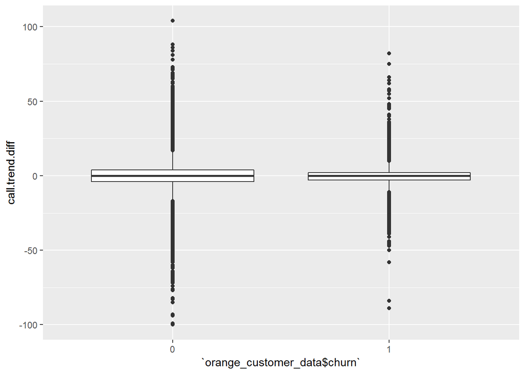

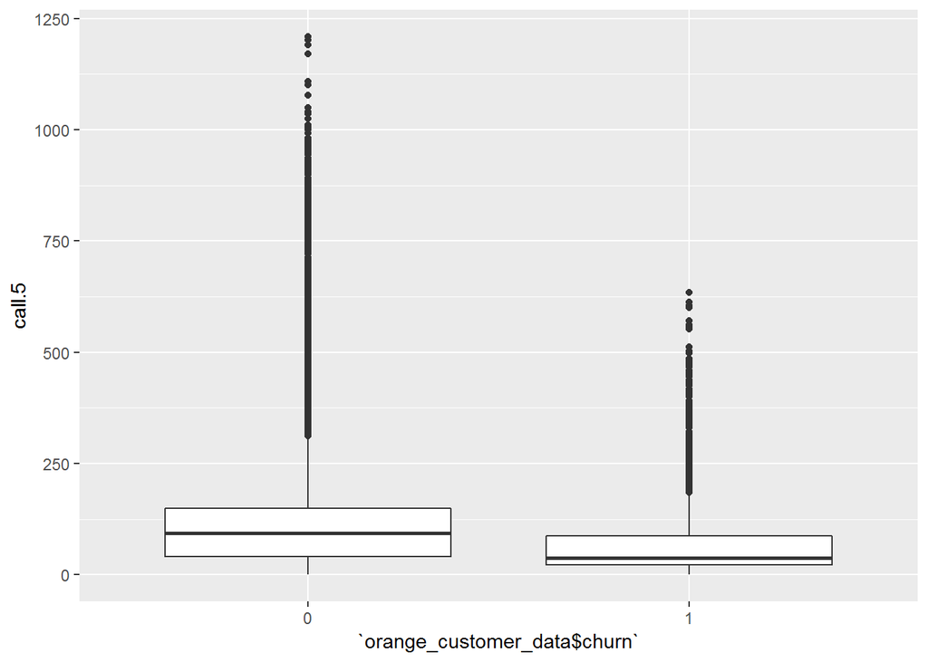

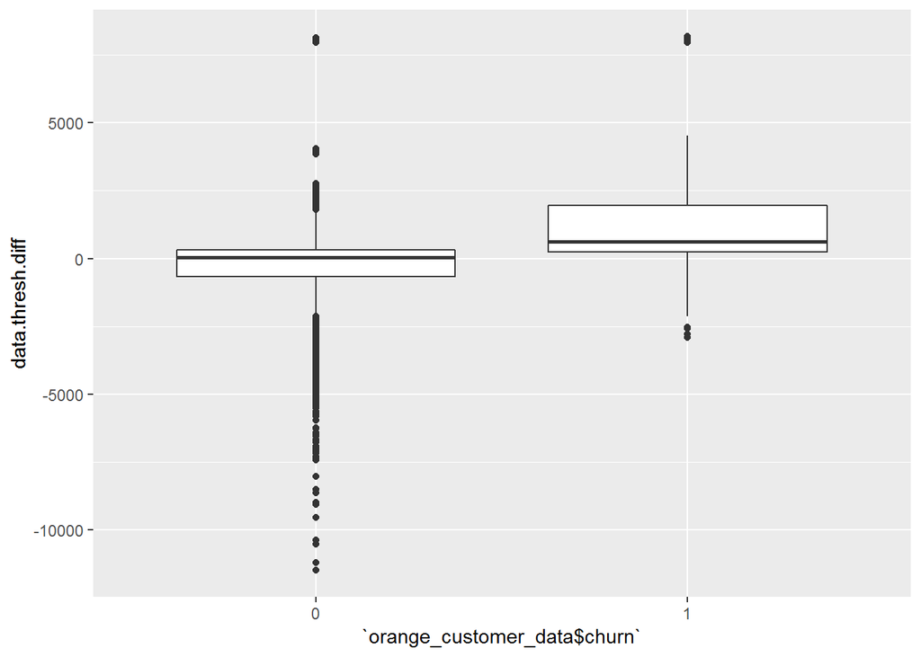

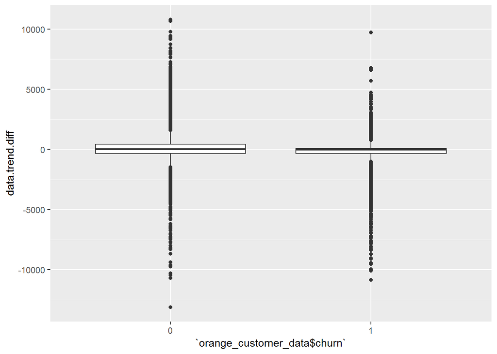

[4 more figures not shown]

As we see from the graphs above, we can see a noticeable difference for customer behavior between the churned and not churned customer for the NETWORK AGE, SERVICE CALLS, SMS THRESHOLD DIFFERENCE, SMS FOR THE PAST 5 MONTHS, CALLS FOR THE LAST FIVE MONTHS, DATA THRESHOLD DIFFERENCE, DATA USAGE TREND DIFFERENCE, AND OFFNET REVENUE for the last 5 months. Thus, we choose these variables for our cluster analysis in order to clearly see typical customer behavior and how their behaviors are related to churning.

```r
#location and churning behavior
table(data.repository1$`orange_customer_data$location` , data.repository1$`orange_customer_data$churn`)
```

```
##
##        0    1
##   1 2287 1002
##   2 1152  523
##   3 1143  524
##   4 1186  490
##   5 2375 1014
##   6 1229  529
##   7 2386 1086
```

```r
str(cluster.data)
```

```
## 'data.frame':    16926 obs. of  8 variables:
##  $ orange_customer_data$network_age  : num  37 91 85 92 82 93 22 80 89 82 ...
##  $ orange_customer_data$service_calls: int  0 0 1 0 0 2 1 0 0 0 ...
##  $ sms.thresh.diff                   : num  42.6 39.2 -33 11.6 40.4 ...
##  $ sms.5                             : num  287 304 165 192 48 ...
##  $ call.5                            : num  31 184 46 38 20 14 48 172 76 38 ...
##  $ data.thresh.diff                  : num  445 -714 150 411 4046 ...
##  $ data.trend.diff                   : num  2 184 219 105 -31 ...
##  $ offnet.revenue.5                  : num  123.8 1212.5 195.2 93.6 104.3 ...
```

```r
#
colMeans(cluster.data)
```

```
##   orange_customer_data$network_age orange_customer_data$service_calls
##                         70.1312773                          0.8002481
##                    sms.thresh.diff                              sms.5
##                          8.8956635                        350.7420536
##                             call.5                   data.thresh.diff
##                        110.9644334                        244.0798062
##                    data.trend.diff                   offnet.revenue.5
##                         -1.0453149                        676.2367903
```

Per regiom, churn rate is almost 30%.

We use k means clustering using four and two clusters.

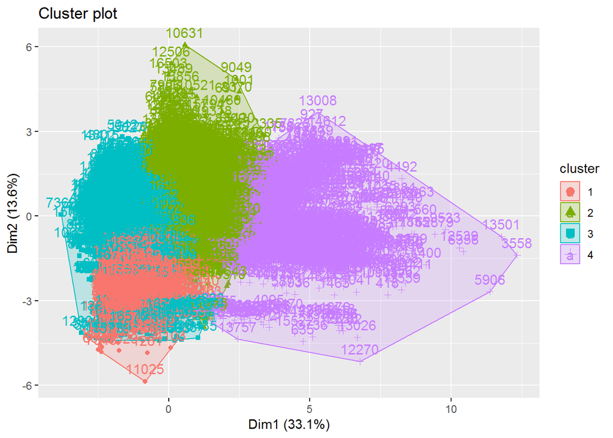

```
##   orange_customer_data$network_age orange_customer_data$service_calls
## 1                       -0.2789557                          3.2113497
## 2                        0.4089849                         -0.2147715
## 3                       -0.3750318                         -0.2051771
## 4                        0.8828357                         -0.3128781
##   sms.thresh.diff      sms.5     call.5 data.thresh.diff data.trend.diff
## 1       0.4893035 -0.3743675 -0.3314461        0.6013209     0.008862111
## 2      -0.1884269  0.4074902  0.2476318       -0.4099509     0.015202155
## 3       0.3139136 -0.4806884 -0.4749036        0.1740259    -0.012041651
## 4      -1.8355854  1.7934802  2.5924855        0.3565667    -0.000177525
##   offnet.revenue.5
## 1       -0.1475933
## 2        0.3935693
## 3       -0.5910124
## 4        2.5000887
```

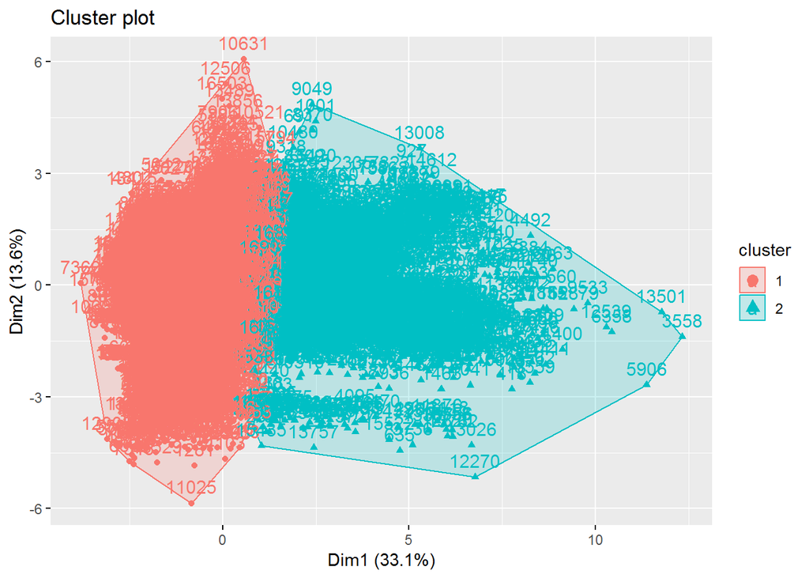

```
##   cluster orange_customer_data$network_age
## 1       1                         66.45303
## 2       2                         87.86963
##   orange_customer_data$service_calls sms.thresh.diff    sms.5    call.5
## 1                          0.8857978        17.64758 276.8202  70.38797
## 2                          0.3876849       -33.31042 707.2298 306.64431
##   data.thresh.diff data.trend.diff offnet.revenue.5
## 1         244.3945       -2.316713         477.2756
## 2         242.5621        5.085999        1635.7264
```

```
##   orange_customer_data$network_age orange_customer_data$service_calls
## 1                       -0.1360990                         0.05699843
## 2                        0.6563371                        -0.27487479
##   sms.thresh.diff      sms.5     call.5 data.thresh.diff data.trend.diff
## 1       0.1967354 -0.2515913 -0.3080278     0.0002040033    -0.001039014
## 2      -0.9487561  1.2132983  1.4854632    -0.0009838056     0.005010644
##   offnet.revenue.5
## 1       -0.3240862
## 2        1.5629050
```

We create two lasso models with two sets of predictors

1. The predictors which are chosen for cluster analysis
2. The predictors that have distinguishing difference between churned and unchurned customers
3. Compare the data through repeated cross validation

```
## 'data.frame':    16926 obs. of  9 variables:
##  $ churned         : Factor w/ 2 levels "0","1": 2 1 1 1 2 2 1 1 1 2 ...
##  $ network_age     : num  37 91 85 92 82 93 22 80 89 82 ...
##  $ service_calls   : int  0 0 1 0 0 2 1 0 0 0 ...
##  $ sms.thresh.diff : num  42.6 39.2 -33 11.6 40.4 ...
##  $ sms.5           : num  287 304 165 192 48 ...
##  $ call.5          : num  31 184 46 38 20 14 48 172 76 38 ...
##  $ data.thresh.diff: num  445 -714 150 411 4046 ...
##  $ data.trend.diff : num  2 184 219 105 -31 ...
##  $ offnet.revenue.5: num  123.8 1212.5 195.2 93.6 104.3 ...
```

```
## [1] 0
```

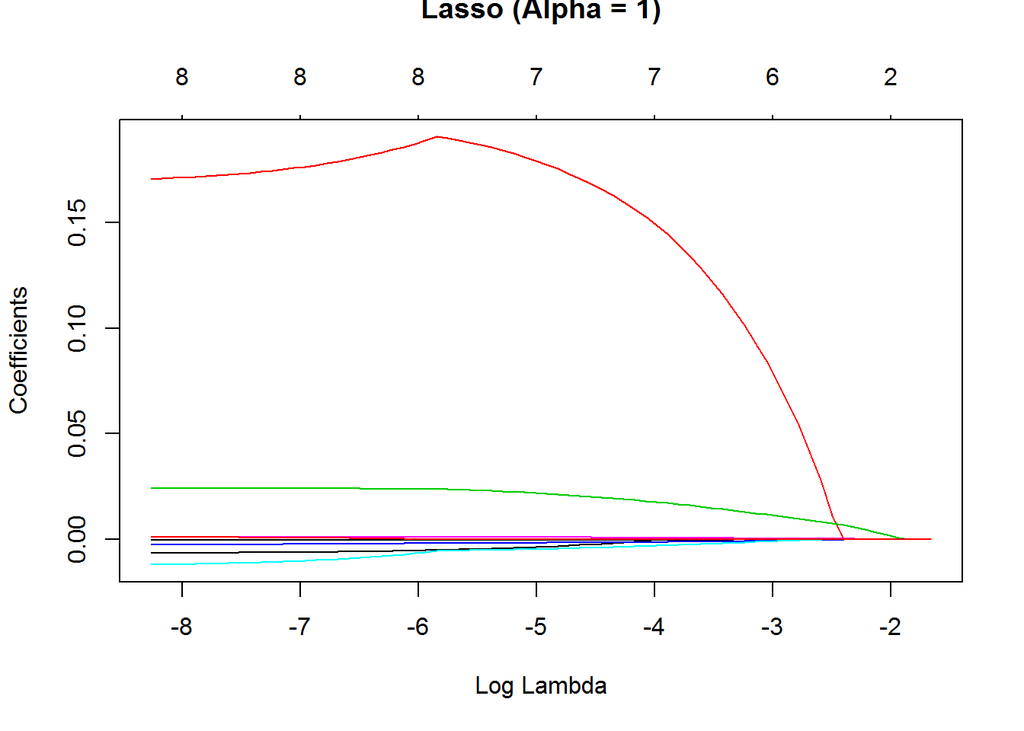

```
##      network_age    service_calls  sms.thresh.diff            sms.5
##       0.00000000       0.01689166       0.34506602      -0.03415826
##           call.5 data.thresh.diff  data.trend.diff offnet.revenue.5
##       0.00000000       0.54603969       0.00000000       0.00000000
```

```
##
## lasso.predict    0    1
##             0 2781  565
##             1  158  727
```

```
## Confusion Matrix and Statistics
##
##           Reference
## Prediction    0    1
##          0 2781  565
##          1  158  727
##
##                Accuracy : 0.8291
##                  95% CI : (0.8174, 0.8403)
##     No Information Rate : 0.6946
##     P-Value [Acc > NIR] : < 2.2e-16
##
##                   Kappa : 0.5582
##  Mcnemar's Test P-Value : < 2.2e-16
##
##             Sensitivity : 0.9462
##             Specificity : 0.5627
##          Pos Pred Value : 0.8311
##          Neg Pred Value : 0.8215
##              Prevalence : 0.6946
##          Detection Rate : 0.6573
##    Detection Prevalence : 0.7908
##       Balanced Accuracy : 0.7545
##
##        'Positive' Class : 0
##
```

```
##  num [1:12695, 1:8] 37 91 85 92 82 93 22 80 89 82 ...
##  - attr(*, "dimnames")=List of 2
##   ..$ : chr [1:12695] "1" "2" "3" "4" ...
##   ..$ : chr [1:8] "network_age" "service_calls" "sms.thresh.diff" "sms.5" ...
```

```
##  num [1:12695, 1:6] 37 91 85 92 82 93 22 80 89 82 ...
##  - attr(*, "dimnames")=List of 2
##   ..$ : chr [1:12695] "1" "2" "3" "4" ...
##   ..$ : chr [1:6] "network_age" "service_calls" "sms.5" "call.5" ...
```

```
##      network_age    service_calls            sms.5           call.5
##       0.00000000       0.02682559      -0.14125742      -0.01805965
##  data.trend.diff offnet.revenue.5
##       0.00000000       0.00000000
```

```
##
## lasso.predict2    0    1
##              0 2818  842
##              1  121  450
```

```
## Confusion Matrix and Statistics
##
##           Reference
## Prediction    0    1
##          0 2818  842
##          1  121  450
##
##                Accuracy : 0.7724
##                  95% CI : (0.7595, 0.785)
##     No Information Rate : 0.6946
##     P-Value [Acc > NIR] : < 2.2e-16
##
##                   Kappa : 0.3641
##  Mcnemar's Test P-Value : < 2.2e-16
##
##             Sensitivity : 0.9588
##             Specificity : 0.3483
##          Pos Pred Value : 0.7699
##          Neg Pred Value : 0.7881
##              Prevalence : 0.6946
##          Detection Rate : 0.6660
##    Detection Prevalence : 0.8650
##       Balanced Accuracy : 0.6536
##
##        'Positive' Class : 0
##
```

Since the 1st Model had higher accuracy And thus we chose the 1st lasso model for its accuracy.

So we have created a model:

logit(Y=Churned) = -0.8877730 + 0.0169 Service Calls + 0.3451 SMS Thresh Diff - 0.0342 5-Month SMS Usage + 0.5460 Data Threshold

For one one unit increase in service calls, the odds of a churned account vs non-churned account increases by 1.0170 For one one unit increase in the difference of actual SMS Actual from the SMS registered amount SMS, the odds of a churned account vs non-churned account increases by 1.4121 For one one unit gincrease in the five month SMS usage, the odds of a churned account vs non-churned account decreases by 0.9664 For one one unit increase in the difference of actual Data used from the registered data amount , the odds of a churned account vs non-churned account increases by 1.7263

## Conclusion

After doing some exploration on customer data and running PCA, cluster analysis, and model builiding with regularization. We have seen that we can reduce 97 variables into 8 reduced one by PCA and categorize the by Low Calls, Low SMS, Low Data Plan and Low Data, Low SMS and Overused Calls, Overused data, Underused SMS and Old Network Age, and Low Number of Registration to Other Promo , high service calls, increasing data users.